# Cirque Meadows lapse rate analysis

Danielle Reimanis

12/11/2019

# Introduction

Lapse rate is often needed for calculating temperature gradients which is important when measuring water resources in mountain driven watersheds.

–> Antonio’s paper –> 6.5°C/km in cascadian mountains paper

#### Reading in iButton data

```r
files <- list.files('data',full.names = T)

my_reader <- function(file){
  data_names = str_split_fixed(file,'_',2)[,1]
  name = gsub('data/','',data_names)
  df <- read_csv(file,) %>%
    dplyr::select(address, name, version, logging_interval)%>%
    rename('date' = 1,
           'temp' = 2)%>%
    mutate(temp = as.numeric(temp))%>%
    slice(-1,-2)%>%
    mutate(site = name)%>%
    mutate(site = replace(site, list=site=="BN29", values="BM29"))%>%
    dplyr::select(date, temp, site)
  return(df)
}

data_clean <- map_dfr(files,my_reader)
```

## Study Area

The mountain campus & Cirque Meadow Trail. High park fire in 2012 New growth/old growth.

```r
utmE <- c(449451, 449437, 449220, 449008, 448513, 448198, 447880, 446903, 449429, 448272, 447472)

utmN <- c(4491181, 4491210, 4491086, 4490502, 4489917, 4489759, 4489705, 4489234, 4491265, 4489694, 4489393)

elev <- c(2787, 2789, 2837, 2853, 2889, 2907, 2911, 3001, 2796.2, 2873, 2955)

site <- c('BM25', 'BM26', 'BM28', 'BM29', 'BM30', 'BM31', 'BM32', 'BM33', 'BM42', 'BM43', 'BM44')

location_data <- cbind(site, utmE, utmN, elev) %>%
  as.data.frame()

location_data_num <- location_data %>%
  mutate(site = as.character(site),
         utmE = as.numeric(as.character(utmE)),
         utmN = as.numeric(as.character(utmN)),
         elev = as.numeric(as.character(elev)))
```

#### Making site data spatial and adding buffer for basemap

```r
spatial_points <- location_data_num %>%
  st_as_sf(coords=c('utmE','utmN'), crs=26913)

buffer_point <- spatial_points %>%
  filter(site == "BM30")

buffer_2km <- st_buffer(buffer_point, 2000)
```

#### Location of 11 sites near the Mountain Campus and up Cirque Meadow Road

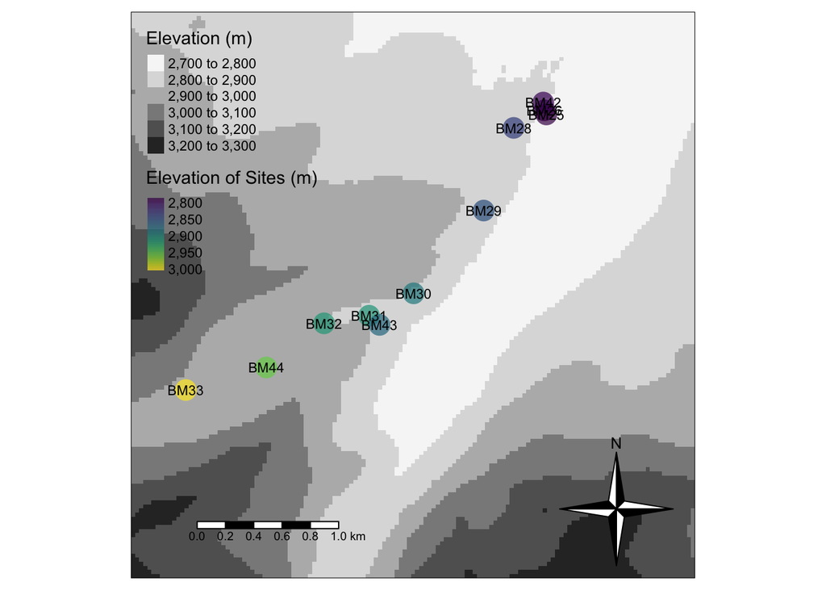

```r
co_elev <- elevatr::get_elev_raster(buffer_2km,z=11)

elev_clip <- crop(co_elev, buffer_2km)

basemap <- tm_shape(elev_clip) +
  tm_raster(palette = 'Greys',
            title = "Elevation (m)")+
  tm_compass(type = "4star", size = 6)+
  tm_scale_bar(position = c(0.1, 0.05), text.size = 0.6)

tm_shape(elev_clip) +
  tm_raster(palette = 'Greys',
            title = "Elevation (m)")+
  tm_shape(spatial_points) +
  tm_dots(col = "elev",
          title = "Elevation of Sites (m)",
          style = "cont",
          size = 1.5,
          palette ='viridis',
          alpha = 0.7)+
  tm_text('site', size = 0.7)+
  tm_compass(type = "4star", size = 6)+
  tm_scale_bar(position = c(0.1, 0.05), text.size = 0.6)
```

**Figure 1:** Location of 11 iButton sites in the Pingree Valley of Larimer County, Colorado. Sites increase in elevation approaching the West, Southwest side of the valley. The maximum change in elevation between sites is 214 meters.

#### Exploring temperature using dygraphs

```r
temp <- data_clean%>%
  dplyr::select(date, temp, site) %>%
  filter(!site == "BM21")%>%
  mutate(date = ymd_hm(date, tz='MST'))

temp_wide <- temp %>%
  spread(., key='site',
         value='temp')%>%
  filter_if(is.numeric, all_vars(!is.na(.)))

temp_xts <- temp_wide %>%
  xts(., order.by = .$date)

dygraph(temp_xts)%>%
  dyAxis('y', label='Temperature (°C)', valueRange=c(-15,40))
```

[interactive chart not shown]

**Figure 2**: Interactive plot exploring hourly temperature at all sites.

# Methods

Pulled data from Dark Sky

# Results

#### Minimum, Average, and Maximum Temperature at the eleven sites

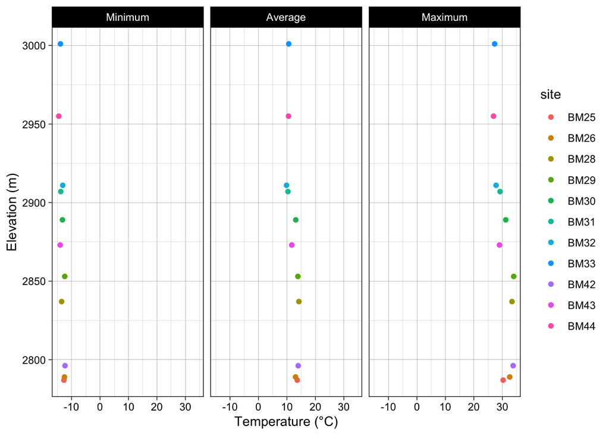

```r
merge_temp_location <- merge(temp, location_data_num, by ='site')

temp_avg_elev <- merge_temp_location%>%
  group_by(site, elev)%>%
  summarise(Maximum = max(temp),
            Average = mean(temp),
            Minimum = min(temp))%>%
  gather(., key = 'type', value = 'temp',
         -site, -elev)

temp_avg_elev$type <- factor(temp_avg_elev$type, levels = c('Minimum', 'Average', 'Maximum'))

ggplot(temp_avg_elev, aes(x=temp, y=elev, color=site))+
  geom_point()+
  theme_linedraw()+
  labs(x= 'Temperature (°C)', y='Elevation (m)')+
  facet_wrap(~type)
```

**Figure 3** Minimum, Average, and Maximum temperature of the eleven sites. Note the spread between the three types of temperature per site.

#### Linear regression using average temperature data (coarse resolution)

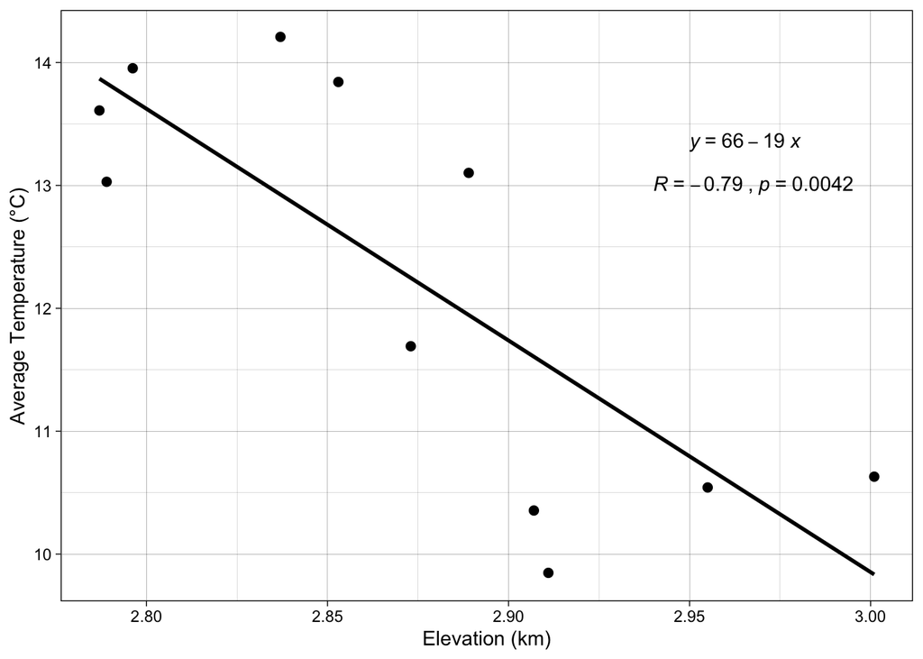

```r
overall_lapse <- merge_temp_location %>%
  group_by(site, elev)%>%
  summarise(avg_temp = mean(temp))%>%
  arrange(desc(elev))%>%
  mutate(elev_km = elev/1000)%>%
  as_tibble()

ggscatter(overall_lapse,
          x = "elev_km",
          y = "avg_temp", add = "reg.line")+
  stat_cor(label.x = 2.94, label.y = 13) +
  stat_regline_equation(label.x = 2.950, label.y = 13.35) +
  labs(x='Elevation (km)', y= 'Average Temperature (°C)')+
  theme_linedraw()
```

**Figure 4** Linear model of average temperature per elevation. The slope of -19 indicates a lapse rate of 19°C per kilometer. This is the coarsest resolution of this lapse rate analysis.

### Linear regression using daily temperature data (medium resolution)

```r
elev_data <- merge_temp_location%>%
  mutate(doy = yday(date))

ydays <- elev_data%>%
  pull(doy)%>%
  unique(.)

lm_fun<- function(x){
  elev_data_fil <- elev_data%>%
    group_by(site,doy)%>%
    summarize(meanTemp = mean(temp),
              elevation= mean(elev))%>%
    filter(doy == x)

  lapse_lm<- lm(meanTemp~elevation,data=elev_data_fil)

}

lapse_lm<- ydays%>%
  map(~lm_fun(.x))%>%
  set_names(ydays)

lapse_lm_sum<- lapse_lm%>%
  map(~summary(.x))

lapse_lm_slopes<- lapse_lm%>%
  map(~coef(.x)[2])%>%
  simplify()%>%
  tibble()%>%
  mutate(doy = ydays)%>%
  rename(lapse_rate=1)%>%
  mutate(lapse_km = lapse_rate*1000)%>%
  mutate(date = as.Date(doy, origin = "2019-01-01"))

lapse_lm_intercept <- lapse_lm %>%
  map(~coef(.x)[1])%>%
  simplify()%>%
  tibble()%>%
  mutate(doy = ydays)%>%
  rename(intercept = 1)%>%
  filter(intercept > 0)%>%
  mutate(date = as.Date(doy, origin = "2019-01-01"))
```

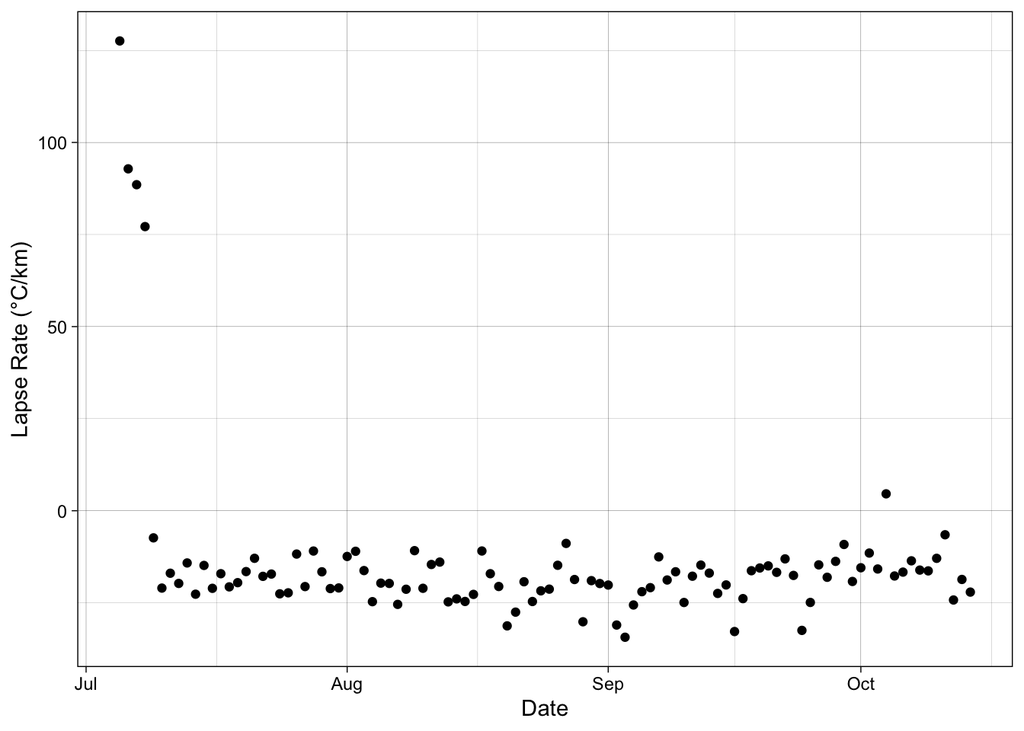

```r
ggplot(lapse_lm_slopes, aes(x=date, y=lapse_km))+
  geom_point()+
  theme_linedraw()+
  labs(x= 'Date', y='Lapse Rate (°C/km)')
```

**Figure 5** Lapse rates in degrees Celsius per kilometer using daily data of the eleven sites. The initial four points are greater than the rest because not all of the sensors were ‘online’ yet, and the three sensors set up were all within 50 meters of each other, but had quite varying average temperatures.

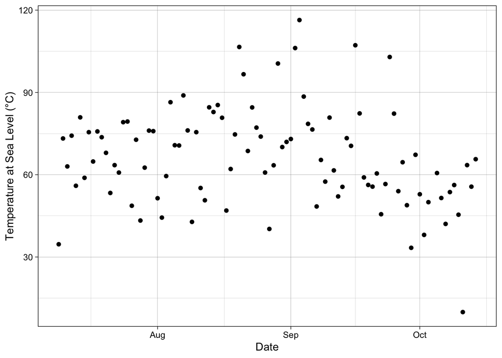

```r
ggplot(lapse_lm_intercept, aes(x=date, y=intercept))+
  geom_point()+
  theme_linedraw()+
  labs(x= 'Date', y='Temperature at Sea Level (°C)')
```

**Figure 6** Coefficients of the daily regression. These would be temperatures at sea level if the lapse rate continued to lower elevations. This figure was included as most of the lapse rate from daily data have unrealistic lapse rate to apply to a larger scale.

### Linear regression using hourly temperature data (fine resolution)

```r
hourly_lapse <- merge_temp_location %>%
  pull(date)

hourly_lm_fn <- function(x){
 filter_temp <- merge_temp_location%>%
    filter(date == x)

  hourly_lapse_lm <- lm(temp ~ elev, data = filter_temp)

}

hr_lapse_lm <- hourly_lapse%>%
  map(~hourly_lm_fn(.x))%>%
  set_names(hourly_lapse)

hr_lapse_summary <- hr_lapse_lm %>%
  map(~summary(.x))

hr_lapse_slopes <- hr_lapse_summary %>%
  map(~coef(.x)[2])%>%
  simplify()%>%
  tibble()%>%
  mutate(date = hourly_lapse)%>%
  rename(lapse_rate = 1)%>%
  mutate(lapse_km = lapse_rate * 1000)
```

#### Plotting Hourly Lapse

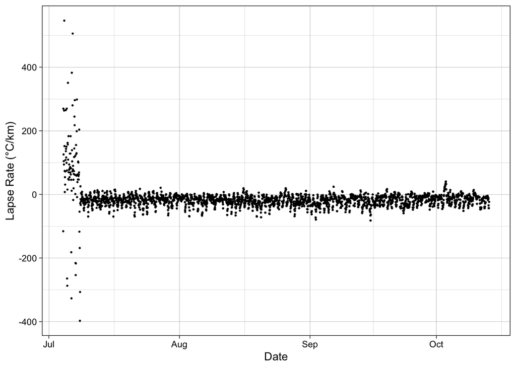

**Figure 7**

#### Calculating hourly lapse rate when all stations were ‘online’

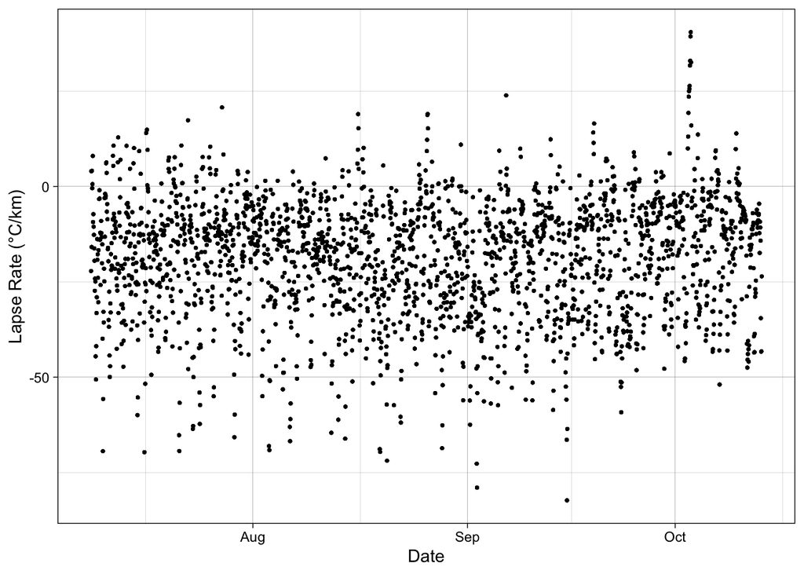

```r
station_count <- merge_temp_location %>%
  arrange(date)%>%
  group_by(date)%>%
  count(site = n())

time_step_all <- station_count %>%
  filter(site == 11)

hr_lapse_corrected <- hr_lapse_slopes %>%
  filter(date > "2019-07-08 15:01:00") %>%
  dplyr::select(2,3)

ggplot(hr_lapse_corrected, aes(x = date, y = lapse_km))+
  geom_point(size = 0.5)+
  theme_linedraw()+
  labs(x= 'Date', y='Lapse Rate (°C/km)')
```

**Figure 8**

#### Plotting intercepts of hourly regression

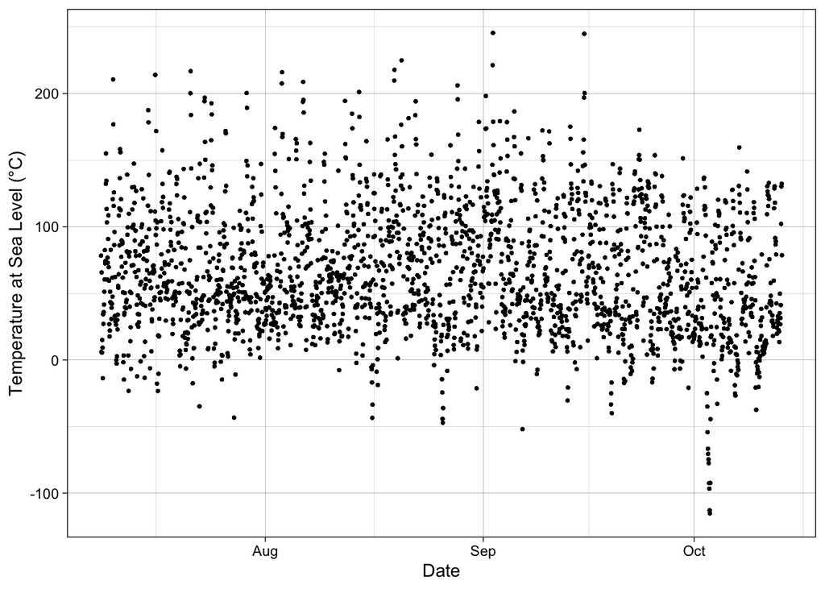

```r
hr_lapse_coef <- hr_lapse_summary %>%
  map(~coef(.x)[1])%>%
  simplify()%>%
  tibble()%>%
  mutate(date = hourly_lapse)%>%
  rename(intercept = 1)%>%
  filter(date > "2019-07-08 15:01:00")

ggplot(hr_lapse_coef, aes(x = date, y = intercept))+
  geom_point(size = 0.5)+
  theme_linedraw()+
  labs(x = 'Date', y = 'Temperature at Sea Level (°C)')
```

**Figure 9**

### Linear regression using day and night data (medium-fine resolution)

#### Pulling Sunrise and Sunset data from Dark Sky

This is commented out as to not request data from Dark Sky without an API key.

```r
latitude <- 40.556899
longitude <- -105.611251

# starting_daily <- get_forecast_for(latitude, longitude, "2019-07-04T01:00:00",
#                                    units = "us", language = "en",
#                                   exclude = 'currently, hourly, minutely',
#                                   add_json = FALSE, add_headers =FALSE)
# combined_daily <- starting_daily$daily%>%
#   dplyr::select(1,4,5)
#
# date_vector <- seq(from = as.Date("2019-07-05"), to = as.Date("2019-10-13"), by = 1)
#
# for(i in as.list(date_vector)){
#     print(i)
#   a_timestamp <- paste(i, "T01:00:00", sep = "")
#   b_forecast <- get_forecast_for(latitude, longitude, a_timestamp,
#                                  units = "us", language = "en",
#                                  exclude = 'currently, hourly, minutely',
#                                  add_json = FALSE, add_headers =FALSE)
#   c_forecast <- b_forecast$daily%>%
#     dplyr::select(1,4,5)
#
#   combined_daily <- rbind(combined_daily, c_forecast)
# }
#
# save(combined_daily, file = './combined_daily.Rdata')

load('./combined_daily.Rdata')
```

#### Merging sunrise/sunset data with temperature data

```r
temp_data <- merge_temp_location %>%
  rename(datetime = date)%>%
  mutate(date = date(datetime))

combined_daily_for_merge <- combined_daily%>%
  mutate(date = seq(from = as.Date("2019-07-04"),
                    to = as.Date("2019-10-13"), by = 1))

temp_sun_data <- merge(temp_data, combined_daily_for_merge, by = 'date')
```

#### Data organized by day/night and averaged

```r
day_and_night <- temp_sun_data %>%
  dplyr::select(-time)%>%
  mutate(day_night = ifelse(datetime > sunriseTime & datetime < sunsetTime,
                            'day', 'night'))%>%
  arrange(datetime)

day_night_average <- day_and_night %>%
  group_by(site, date, day_night)%>%
  summarise(avg_temp = mean(temp),
            elev = mean(elev),
            utmE = mean(utmE),
            utmN = mean(utmN))%>%
  arrange(date)
```

#### Plotting Day vs Night Averages

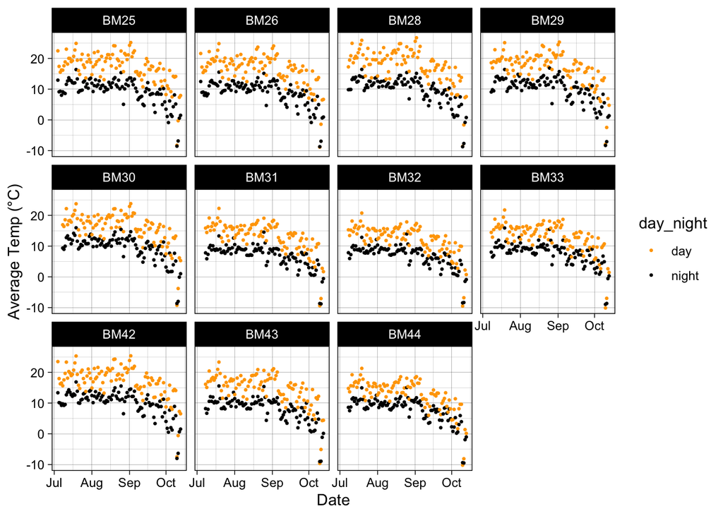

```r
ggplot(day_night_average, aes(x=date, y=avg_temp))+
  geom_point(size =0.5, aes(color = day_night))+
  scale_color_manual(values = c("orange", "black"))+
  facet_wrap(~site)+
  theme_linedraw()+
  labs(x='Date', y= 'Average Temp (°C)')
```

**Figure 10**

#### Day and night regression

```r
day_night_wide <- day_night_average %>%
  spread(., key = 'day_night',
         value = 'avg_temp')%>%
  mutate(doy = yday(date))%>%
  arrange(doy)%>%
  mutate(elev_km = elev/1000)

ydays <- day_night_wide %>%
  mutate(doy = yday(date))%>%
  pull(doy)%>%
  unique()

day_lm_fun <- function(x){
 filter_temp <- day_night_wide%>%
    filter(doy == x)

  daily_lapse_lm <- lm(day~elev_km, data = filter_temp)
}

day_lm <- ydays%>%
  map(~day_lm_fun(.x))%>%
  set_names(ydays)

day_lm_slopes <- day_lm%>%
  map(~coef(.x)[2])%>%
  simplify()%>%
  tibble()%>%
  rename(Day = 1)%>%
  mutate(date = seq(from = as.Date("2019-07-04"),
                    to = as.Date("2019-10-13"), by = 1))


night_lm_fun <- function(x){
 filter_temp <- day_night_wide%>%
    filter(doy == x)

  daily_lapse_lm <- lm(night ~ elev_km, data = filter_temp)
}

night_lm <- ydays%>%
  map(~night_lm_fun(.x))%>%
  set_names(ydays)

night_lm_slopes <- night_lm%>%
  map(~coef(.x)[2])%>%
  simplify()%>%
  tibble()%>%
  rename(Night = 1)%>%
  mutate(date = seq(from = as.Date("2019-07-04"),
                    to = as.Date("2019-10-13"), by = 1))
```

#### Joining Night and Day Linear Models and Plotting

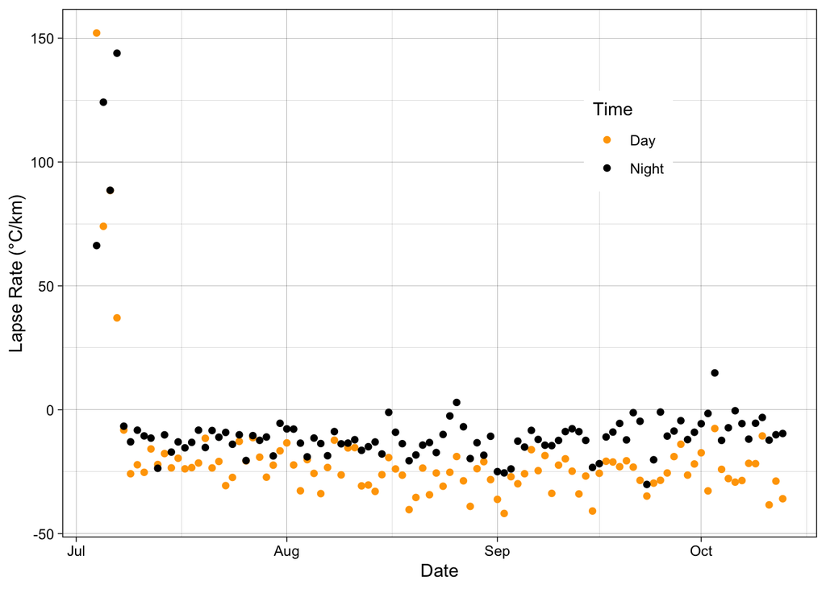

```r
night_day_lm <- merge(day_lm_slopes, night_lm_slopes, by = 'date')

night_day_slopes_long <- night_day_lm %>%
  gather(., key = 'Time',
         value = 'lapse_rate',
         -date)

ggplot(night_day_slopes_long, aes(x=date, y=lapse_rate))+
  geom_point(aes(color = Time))+
  scale_color_manual(values = c("orange", "black"))+
  theme_linedraw()+
  theme(legend.position = c(0.75, 0.75))+
  labs(x = 'Date', y = 'Lapse Rate (°C/km)')
```

**Figure 11**

#### Zoomed in, while all iButtons were ‘online’

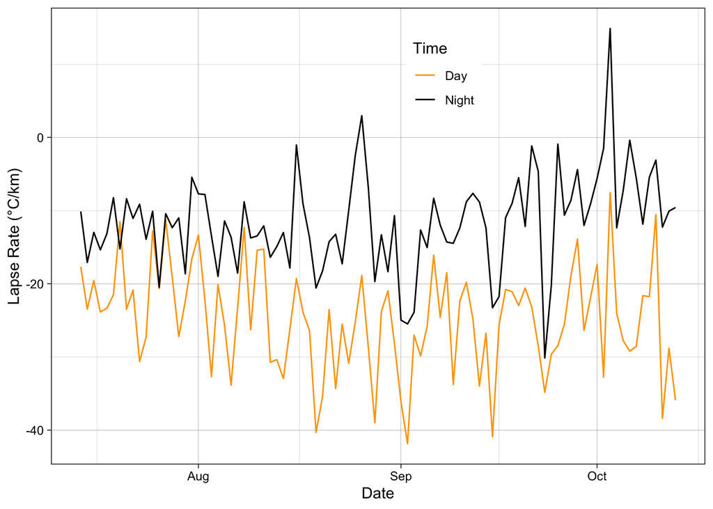

```r
online_night_day_slope <- night_day_slopes_long%>%
  filter(date > "2019-07-13")

ggplot(online_night_day_slope, aes(x=date, y=lapse_rate))+
  geom_line(aes(color = Time))+
  scale_color_manual(values = c("orange", "black"))+
  theme_linedraw()+
  theme(legend.position = c(0.6, 0.85))+
  labs(x = 'Date', y = 'Lapse Rate (°C/km)')
```

**Figure 12**

#### Pulling R<sup>2</sup> Values

```r
day_lm_sum_r <- day_lm %>%
  map(~summary(.x)$r.squared)%>%
  tibble()%>%
  rename(Day = 1)%>%
  mutate(date = seq(from = as.Date("2019-07-04"),
                    to = as.Date("2019-10-13"), by = 1))

night_lm_sum_r <- night_lm %>%
  map(~summary(.x)$r.squared)%>%
  tibble()%>%
  rename(Night = 1)%>%
  mutate(date = seq(from = as.Date("2019-07-04"),
                    to = as.Date("2019-10-13"), by = 1))

day_night_r <- merge(day_lm_sum_r, night_lm_sum_r, by = 'date')

day_night_r_long <- day_night_r %>%
  gather(., key = 'Time',
         value = 'R_squared',
         -date)

r_plotting_ready <- day_night_r_long %>%
  mutate(R_squared = as.numeric(as.list(R_squared)))%>%
  rename(dateR = 1, TimeR = 2)
```

## Plotting R<sup>2</sup> Values and creating data frame with slope and R Squared

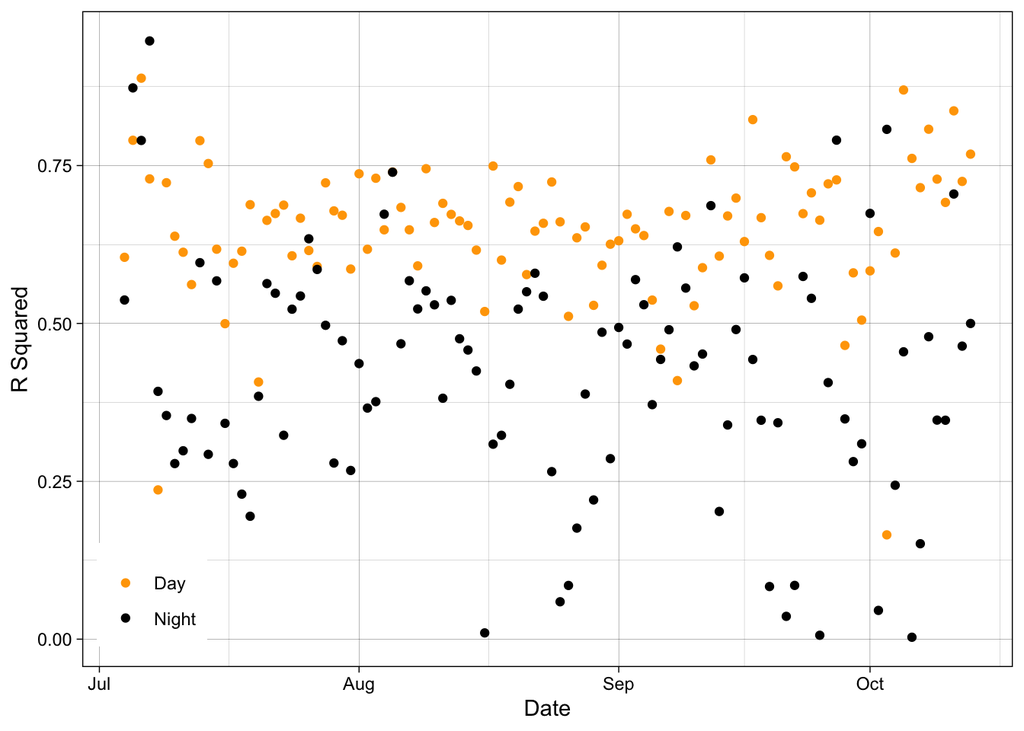

```r
slope_R_all <- cbind(r_plotting_ready, night_day_slopes_long)%>%
  dplyr::select(3,4:6)

ggplot(r_plotting_ready, aes(x=dateR, y= R_squared))+
  geom_point(aes(color = TimeR))+
  scale_color_manual(values = c("orange", "black"))+
  theme_linedraw()+
  theme(legend.position = c(0.075, 0.11), legend.title=element_blank())+
  labs(x = 'Date', y = 'R Squared')
```

**Figure 13**

## Plotting R squared values and slopes (with and without correction)

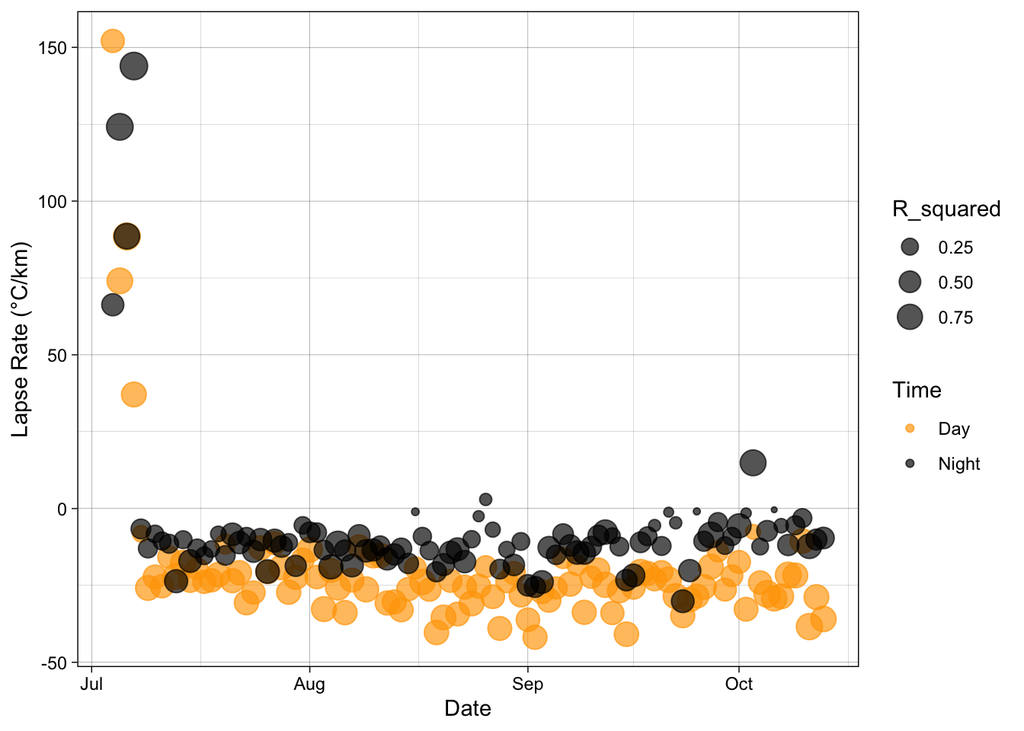

```r
ggplot(slope_R_all, aes(x=date, y=lapse_rate, size=R_squared))+
  geom_point(alpha=0.67, aes(color=Time))+
  scale_color_manual(values = c("orange", "black"))+
  theme_linedraw()+
  labs(x = 'Date', y = 'Lapse Rate (°C/km)')
```

**Figure 14**

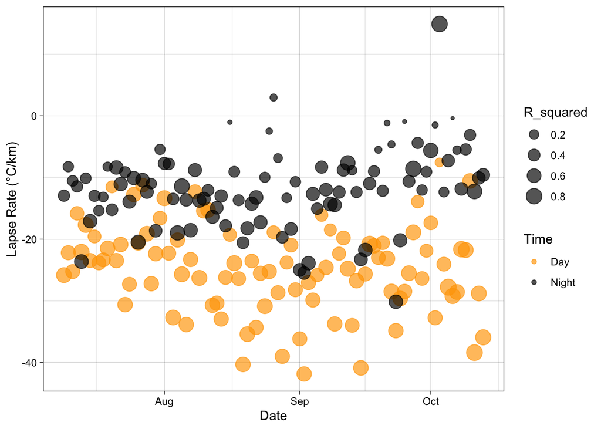

```r
slope_R_online <- slope_R_all %>%
  filter(date > "2019-07-08")

ggplot(slope_R_online, aes(x=date, y=lapse_rate, size=R_squared))+
  geom_point(alpha=0.67, aes(color=Time))+
  scale_color_manual(values = c("orange", "black"))+
  theme_linedraw()+
  labs(x = 'Date', y = 'Lapse Rate (°C/km)')
```

**Figure 15**

# Discussion

Overall trends, but more importantly what to do next!

–> Antonio’s paper –> 6.5°C/km in cascadian mountains paper???